# MentalHealthFinal

2024-11-18

```r
library(dplyr)
```

```r
library(ggplot2)
mh <- read.csv("mental_health_dataset.csv")
```

## 1. Data Cleaning

```r
mh <- mh %>%
  mutate(Gender = case_when(
    Gender %in% c("Male") ~ "Male",
    Gender %in% c("Female") ~ "Female",
    TRUE ~ "Other/Didn't Say"
  ))

mh$Gender <- as.factor(mh$Gender)
mh$Occupation <- as.factor(mh$Occupation)
mh$Country <- as.factor(mh$Country)
mh$Severity <- factor(mh$Severity, levels = c("None", "Low", "Medium", "High"), ordered = TRUE)
mh$Mental_Health_Condition <- as.factor(mh$Mental_Health_Condition)
mh$Stress_Level <- factor(mh$Stress_Level, levels = c("Low", "Medium", "High"), ordered = TRUE)
mh$Consultation_History <- as.factor(mh$Consultation_History)
```

## 2. Data Exploration

### Stress Level by Sleep

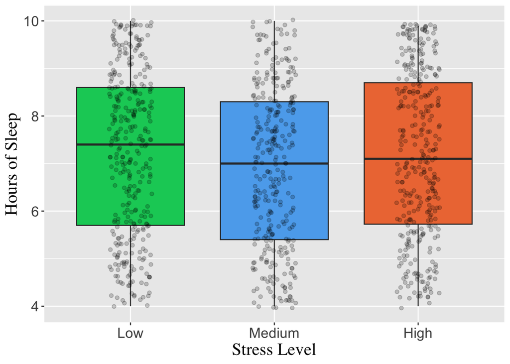

```r
ggplot(mh, aes(x = Stress_Level, y = Sleep_Hours, fill = Stress_Level)) +
  geom_boxplot() +
  scale_fill_manual(values = c("Low" = "springgreen3", "Medium" = "steelblue2", "High" = "sienna2")) +
  geom_jitter(alpha = 0.2, width = .15) +
  theme(
    legend.position = "none",
    axis.title = element_text(size = 17, family = "serif"),
    axis.text.x = element_text(size = 14),
    axis.text.y = element_text(size = 14)
  ) +
  xlab("Stress Level") +
  ylab("Hours of Sleep")
```

```r
aov_result <- aov(Sleep_Hours ~ Stress_Level, data = mh)
summary(aov_result)
```

```
##               Df Sum Sq Mean Sq F value Pr(>F)
## Stress_Level   2   13.7    6.83   2.331 0.0977 .
## Residuals    997 2920.7    2.93
## ---
## Signif. codes:  0 '***' 0.001 '**' 0.01 '*' 0.05 '.' 0.1 ' ' 1
```

### Stress Level by Work

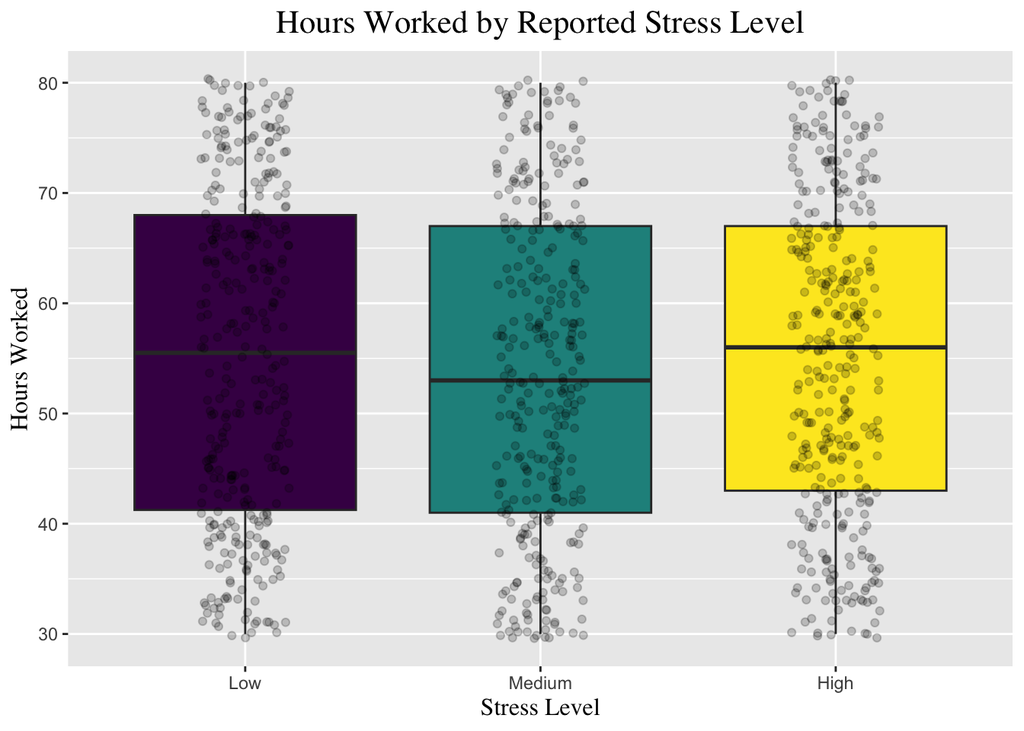

```r
ggplot(mh, aes(x = Stress_Level, y = Work_Hours, fill = Stress_Level)) +
  geom_boxplot() +
  geom_jitter(alpha = 0.2, width = .15) +
  ggtitle("Hours Worked by Reported Stress Level") +
  theme(
    legend.position = "none",
    plot.title = element_text(hjust = 0.5, size = 16, family = "serif"),
    axis.title = element_text(size = 12, family = "serif")
  ) +
  xlab("Stress Level") +
  ylab("Hours Worked")
```

```r
aov_result <- aov(Work_Hours ~ Stress_Level, data = mh)
summary(aov_result)
```

```
##               Df Sum Sq Mean Sq F value Pr(>F)
## Stress_Level   2    433   216.3       1  0.368
## Residuals    997 215707   216.4
```

### Stress Level by Physical Activity

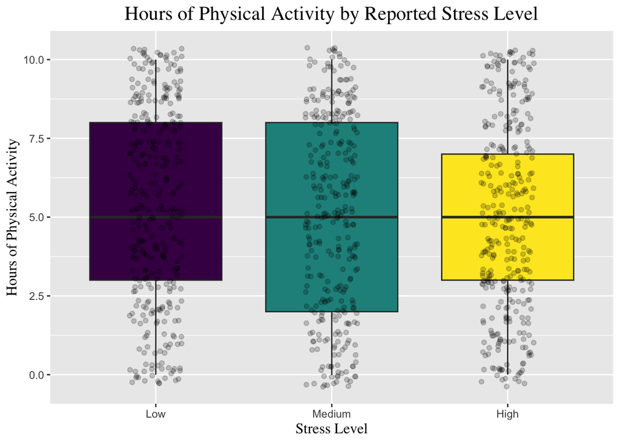

```r
ggplot(mh, aes(x = Stress_Level, y = Physical_Activity_Hours, fill = Stress_Level)) +
  geom_boxplot() +
  geom_jitter(alpha = 0.2, width = .15) +
  ggtitle("Hours of Physical Activity by Reported Stress Level") +
  theme(
    legend.position = "none",
    plot.title = element_text(hjust = 0.5, size = 16, family = "serif"),
    axis.title = element_text(size = 12, family = "serif")
  ) +
  xlab("Stress Level") +
  ylab("Hours of Physical Activity")
```

```r
aov_result <- aov(Physical_Activity_Hours ~ Stress_Level, data = mh)
summary(aov_result)
```

```
##               Df Sum Sq Mean Sq F value Pr(>F)
## Stress_Level   2     30  15.139   1.596  0.203
## Residuals    997   9458   9.486
```

### Stress Level by Age

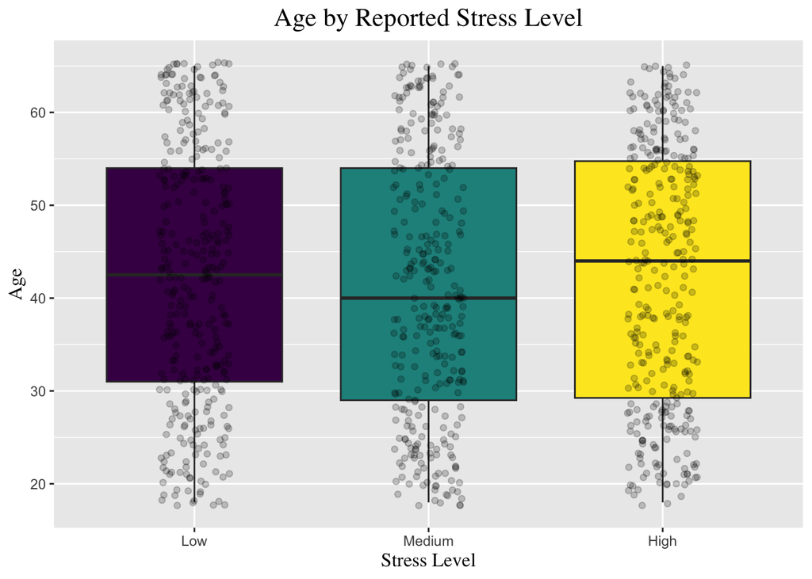

```r
ggplot(mh, aes(x = Stress_Level, y = Age, fill = Stress_Level)) +
  geom_boxplot() +
  geom_jitter(alpha = 0.2, width = .15) +
  ggtitle("Age by Reported Stress Level") +
  theme(
    legend.position = "none",
    plot.title = element_text(hjust = 0.5, size = 16, family = "serif"),
    axis.title = element_text(size = 12, family = "serif")
  ) +
  xlab("Stress Level") +
  ylab("Age")
```

```r
aov_result <- aov(Age ~ Stress_Level, data = mh)
summary(aov_result)
```

```
##               Df Sum Sq Mean Sq F value Pr(>F)
## Stress_Level   2    257   128.7   0.659  0.518
## Residuals    997 194841   195.4
```

### Stress Level by Gender

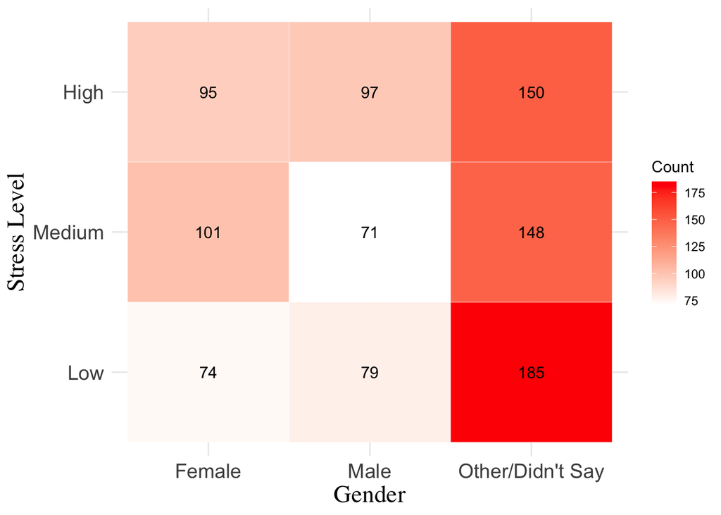

```r
counts <- mh %>%
  group_by(Gender, Stress_Level) %>%
  summarise(Count = n(), .groups = "drop")

ggplot(counts, aes(x = Gender, y = Stress_Level, fill = Count)) +
  geom_tile(color = "white") + # Create tiles with borders
  geom_text(aes(label = Count), color = "black", size = 4) + # Add counts as text
  scale_fill_gradient(low = "white", high = "red") + # Adjust the color gradient
  theme_minimal() + # Minimal theme
  labs(
    x = "Gender",
    y = "Stress Level",
    fill = "Count"
  ) +
  theme(
    axis.title = element_text(size = 17, family = "serif"),
    axis.text.x = element_text(size = 14),
    axis.text.y = element_text(size = 14)
  )
```

```r
contingency_table <- table(mh$Stress_Level, mh$Gender)
chisq.results <- chisq.test(contingency_table)
print(chisq.results)
```

```
##
##  Pearson's Chi-squared test
##
## data:  contingency_table
## X-squared = 13.296, df = 4, p-value = 0.009918
```

```r
chisq.results$stdres
```

```
##
##              Female       Male Other/Didn't Say
##   Low    -2.5990231 -0.6953860        2.9091975
##   Medium  2.2293595 -1.2638067       -0.8899294
##   High    0.3994039  1.9361564       -2.0258093
```

Females are more unlikely to have low stress levels Males are a little more likely to have high stress levels Other/Didn’t Say are more likely to have low stress levels

### Stress Level by Country

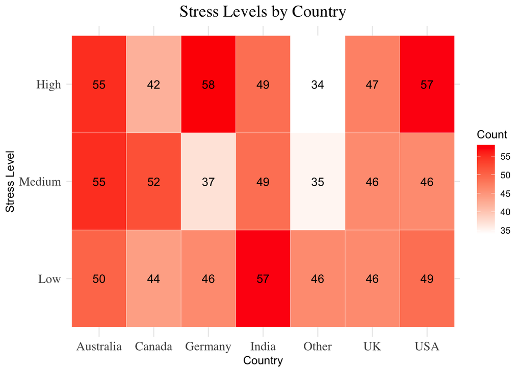

```r
counts <- mh %>%
  group_by(Country, Stress_Level) %>%
  summarise(Count = n(), .groups = "drop")

ggplot(counts, aes(x = Country, y = Stress_Level, fill = Count)) +
  geom_tile(color = "white") + # Create tiles with borders
  geom_text(aes(label = Count), color = "black", size = 4) + # Add counts as text
  scale_fill_gradient(low = "white", high = "red") + # Adjust the color gradient
  theme_minimal() + # Minimal theme
  labs(
    title = "Stress Levels by Country",
    x = "Country",
    y = "Stress Level",
    fill = "Count"
  ) +
  theme(
    plot.title = element_text(hjust = 0.5, size = 16, family = "serif"),
    axis.text = element_text(size = 12, family = "serif")
  )
```

```r
contingency_table <- table(mh$Stress_Level, mh$Country)
chisq.test(contingency_table)
```

```
##
##  Pearson's Chi-squared test
##
## data:  contingency_table
## X-squared = 9.857, df = 12, p-value = 0.6285
```

### Stress Level by Occupation

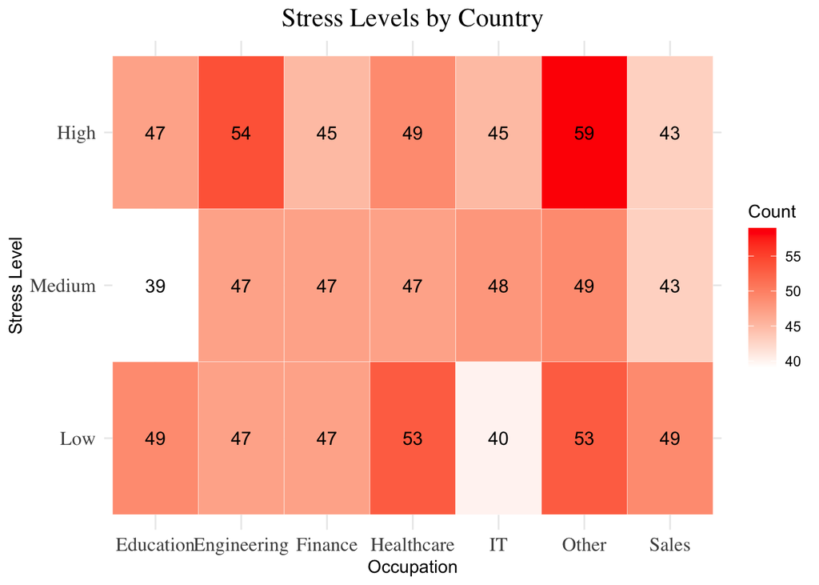

```r
counts <- mh %>%
  group_by(Occupation, Stress_Level) %>%
  summarise(Count = n(), .groups = "drop")

ggplot(counts, aes(x = Occupation, y = Stress_Level, fill = Count)) +
  geom_tile(color = "white") + # Create tiles with borders
  geom_text(aes(label = Count), color = "black", size = 4) + # Add counts as text
  scale_fill_gradient(low = "white", high = "red") + # Adjust the color gradient
  theme_minimal() + # Minimal theme
  labs(
    title = "Stress Levels by Country",
    x = "Occupation",
    y = "Stress Level",
    fill = "Count"
  ) +
  theme(
    plot.title = element_text(hjust = 0.5, size = 16, family = "serif"),
    axis.text = element_text(size = 12, family = "serif")
  )
```

```r
contingency_table <- table(mh$Stress_Level, mh$Occupation)
chisq.test(contingency_table)
```

```
##
##  Pearson's Chi-squared test
##
## data:  contingency_table
## X-squared = 3.7411, df = 12, p-value = 0.9877
```

### Mental Health Condition by Gender

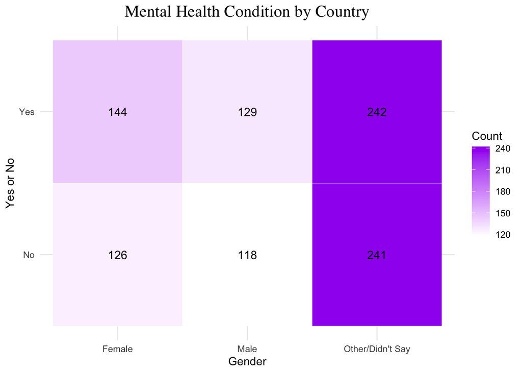

```r
counts <- mh %>%
  group_by(Gender, Mental_Health_Condition) %>%
  summarise(Count = n(), .groups = "drop")

ggplot(counts, aes(x = Gender, y = Mental_Health_Condition, fill = Count)) +
  geom_tile(color = "white") + # Create tiles with borders
  geom_text(aes(label = Count), color = "black", size = 4) + # Add counts as text
  scale_fill_gradient(low = "white", high = "purple") + # Adjust the color gradient
  theme_minimal() + # Minimal theme
  labs(
    title = "Mental Health Condition by Country",
    x = "Gender",
    y = "Yes or No",
    fill = "Count"
  ) +
  theme(
    plot.title = element_text(hjust = 0.5, size = 16, family = "serif")
  )
```

```r
contingency_table <- table(mh$Mental_Health_Condition, mh$Gender)
chisq.test(contingency_table)
```

```
##
##  Pearson's Chi-squared test
##
## data:  contingency_table
## X-squared = 0.79266, df = 2, p-value = 0.6728
```

### Mental Health Condition by Country

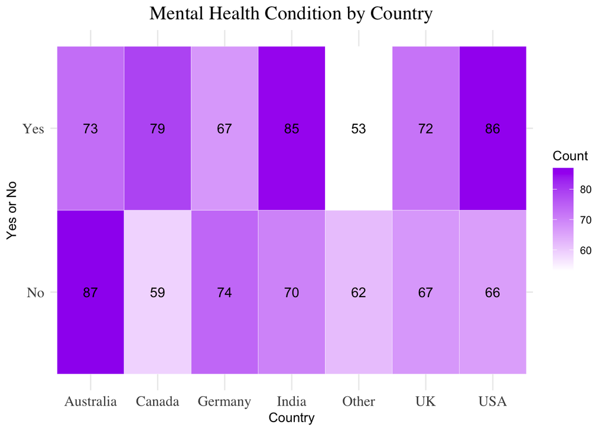

```r
counts <- mh %>%
  group_by(Country, Mental_Health_Condition) %>%
  summarise(Count = n(), .groups = "drop")

ggplot(counts, aes(x = Country, y = Mental_Health_Condition, fill = Count)) +
  geom_tile(color = "white") + # Create tiles with borders
  geom_text(aes(label = Count), color = "black", size = 4) + # Add counts as text
  scale_fill_gradient(low = "white", high = "purple") + # Adjust the color gradient
  theme_minimal() + # Minimal theme
  labs(
    title = "Mental Health Condition by Country",
    x = "Country",
    y = "Yes or No",
    fill = "Count"
  ) +
  theme(
    plot.title = element_text(hjust = 0.5, size = 16, family = "serif"),
    axis.text = element_text(size = 12, family = "serif")
  )
```

```r
contingency_table <- table(mh$Mental_Health_Condition, mh$Country)
chisq.test(contingency_table)
```

```
##
##  Pearson's Chi-squared test
##
## data:  contingency_table
## X-squared = 8.5462, df = 6, p-value = 0.2008
```

### Mental Health Condition by Occupation

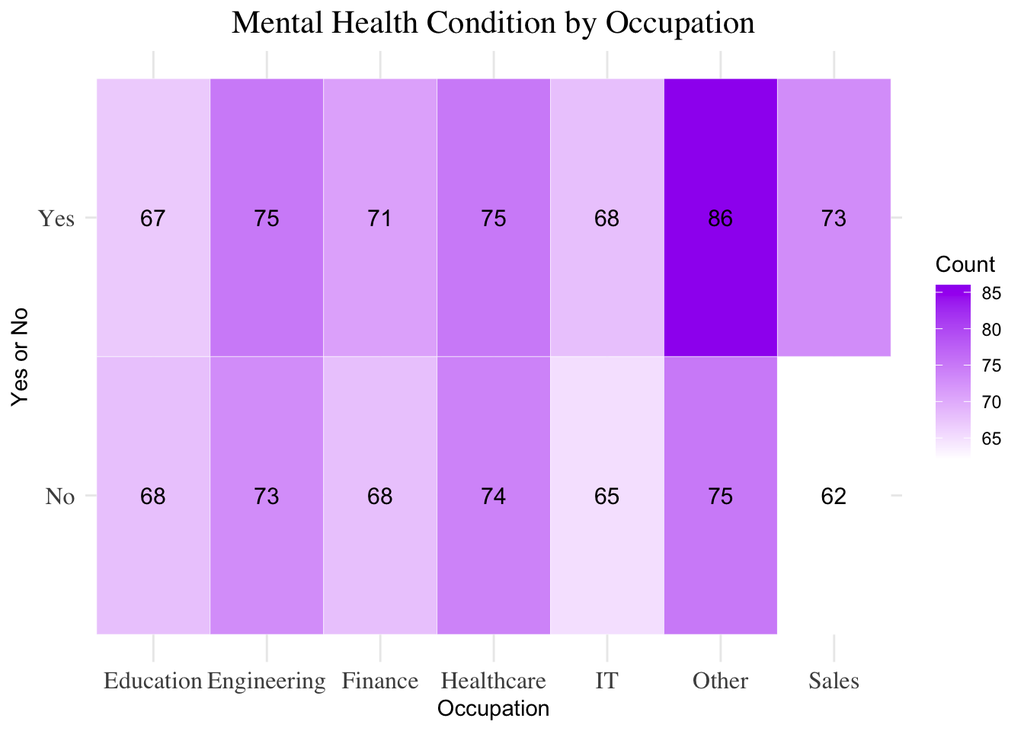

```r
counts <- mh %>%
  group_by(Occupation, Mental_Health_Condition) %>%
  summarise(Count = n(), .groups = "drop")

ggplot(counts, aes(x = Occupation, y = Mental_Health_Condition, fill = Count)) +
  geom_tile(color = "white") + # Create tiles with borders
  geom_text(aes(label = Count), color = "black", size = 4) + # Add counts as text
  scale_fill_gradient(low = "white", high = "purple") + # Adjust the color gradient
  theme_minimal() + # Minimal theme
  labs(
    title = "Mental Health Condition by Occupation",
    x = "Occupation",
    y = "Yes or No",
    fill = "Count"
  ) +
  theme(
    plot.title = element_text(hjust = 0.5, size = 16, family = "serif"),
    axis.text = element_text(size = 12, family = "serif")
  )
```

```r
contingency_table <- table(mh$Mental_Health_Condition, mh$Occupation)
chisq.test(contingency_table)
```

```
##
##  Pearson's Chi-squared test
##
## data:  contingency_table
## X-squared = 0.92224, df = 6, p-value = 0.9884
```

### Stress Level by Mental Health Condition

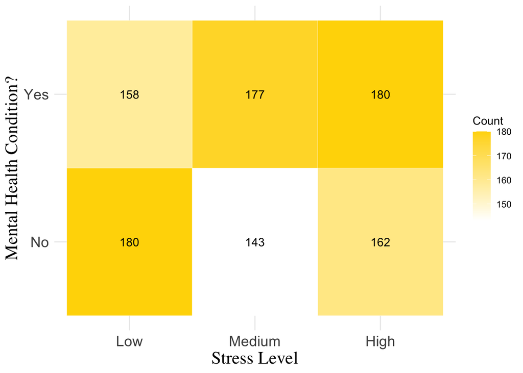

```r
counts <- mh %>%
  group_by(Stress_Level, Mental_Health_Condition) %>%
  summarise(Count = n(), .groups = "drop")

ggplot(counts, aes(x = Stress_Level, y = Mental_Health_Condition, fill = Count)) +
  geom_tile(color = "white") + # Create tiles with borders
  geom_text(aes(label = Count), color = "black", size = 4) + # Add counts as text
  scale_fill_gradient(low = "white", high = "gold") + # Adjust the color gradient
  theme_minimal() + # Minimal theme
  labs(
    x = "Stress Level",
    y = "Mental Health Condition?",
    fill = "Count"
  ) +
  theme(
    axis.title = element_text(size = 17, family = "serif"),
    axis.text.x = element_text(size = 14),
    axis.text.y = element_text(size = 14)
  )
```

```r
contingency_table <- table(mh$Stress_Level, mh$Mental_Health_Condition)
chisq.results <- chisq.test(contingency_table)
print(chisq.results)
```

```
##
##  Pearson's Chi-squared test
##
## data:  contingency_table
## X-squared = 5.0964, df = 2, p-value = 0.07822
```

```r
chisq.results$stdres
```

```
##
##                  No        Yes
##   Low     2.1495822 -2.1495822
##   Medium -1.6548396  1.6548396
##   High   -0.5161911  0.5161911
```

People without mental health conditions are more likely to have low stress levels. People with mental health conditions are less likely to have low stress levels.

## 3. Decision Trees

### Stress Level Decision Tree

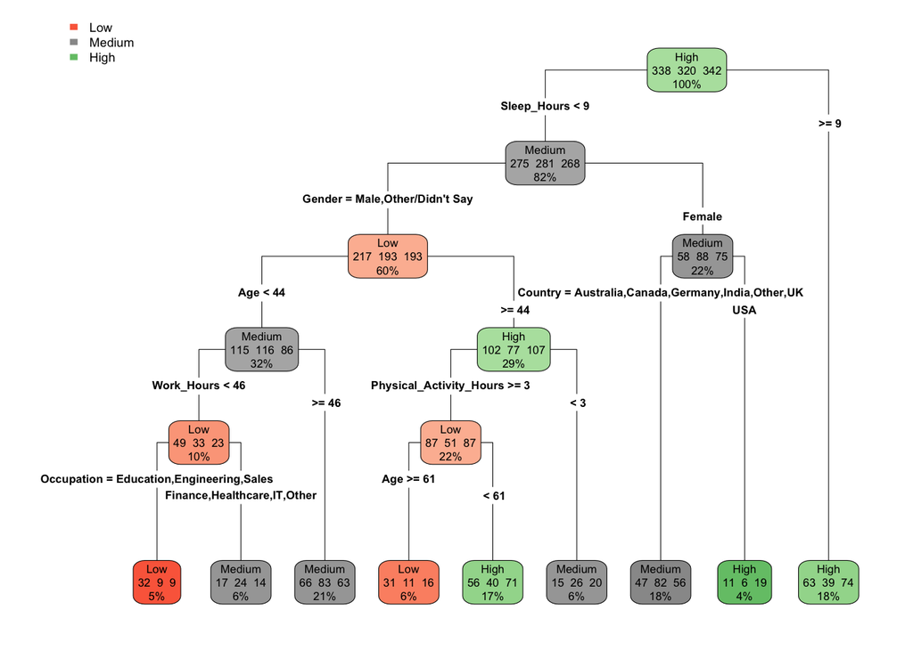

```r
library(rpart)
library(rpart.plot)
# Build the model
tree_model <- rpart(Stress_Level ~ Age + Gender + Occupation + Country +
                      Mental_Health_Condition + Severity + Consultation_History +
                      Sleep_Hours + Work_Hours + Physical_Activity_Hours,
                      data = mh, method = "class")

# Visualize the tree
rpart.plot(tree_model, type = 4, extra = 101)
```

```r
# Evaluate predictions
predictions <- predict(tree_model, mh, type = "class")
confusion_matrix <- table(Predicted = predictions, Actual = mh$Stress_Level)
print(confusion_matrix)
```

```
##          Actual
## Predicted Low Medium High
##    Low     63     20   25
##    Medium 145    215  153
##    High   130     85  164
```

```r
# Display the complexity parameter table
printcp(tree_model)
```

```
##
## Classification tree:
## rpart(formula = Stress_Level ~ Age + Gender + Occupation + Country +
##     Mental_Health_Condition + Severity + Consultation_History +
##     Sleep_Hours + Work_Hours + Physical_Activity_Hours, data = mh,
##     method = "class")
##
## Variables actually used in tree construction:
## [1] Age                     Country                 Gender
## [4] Occupation              Physical_Activity_Hours Sleep_Hours
## [7] Work_Hours
##
## Root node error: 658/1000 = 0.658
##
## n= 1000
##
##         CP nsplit rel error xerror     xstd
## 1 0.028116      0   1.00000 1.0395 0.022343
## 2 0.019757      2   0.94377 1.0334 0.022418
## 3 0.016717      3   0.92401 1.0137 0.022650
## 4 0.015957      5   0.89058 1.0258 0.022510
## 5 0.010638      7   0.85866 1.0137 0.022650
## 6 0.010000      8   0.84802 1.0152 0.022632
```

Even after 8 splits, the relative error is 0.848. This means the error was reduced by about 15% from the error at the root.

## Mental Health Condition Decision Tree

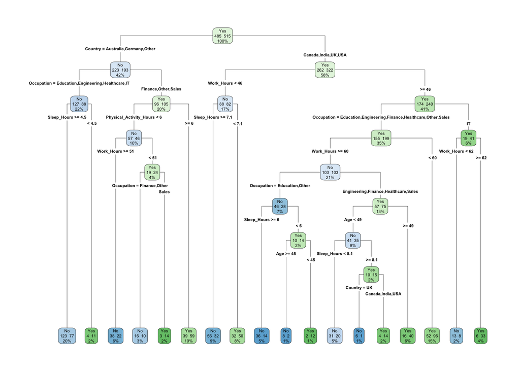

```r
library(rpart)
library(rpart.plot)

# Build the model
tree_model <- rpart(Mental_Health_Condition ~ Age + Gender + Occupation + Country +
                      Stress_Level + Consultation_History +
                      Sleep_Hours + Work_Hours + Physical_Activity_Hours,
                      data = mh, method = "class")

# Visualize the tree
rpart.plot(tree_model, type = 4, extra = 101)
```

```r
# Evaluate predictions
predictions <- predict(tree_model, mh, type = "class")
confusion_matrix <- table(Predicted = predictions, Actual = mh$Mental_Health_Condition)
print(confusion_matrix)
```

```
##          Actual
## Predicted  No Yes
##       No  327 186
##       Yes 158 329
```

```r
# Display the complexity parameter table
printcp(tree_model)
```

```
##
## Classification tree:
## rpart(formula = Mental_Health_Condition ~ Age + Gender + Occupation +
##     Country + Stress_Level + Consultation_History + Sleep_Hours +
##     Work_Hours + Physical_Activity_Hours, data = mh, method = "class")
##
## Variables actually used in tree construction:
## [1] Age                     Country                 Occupation
## [4] Physical_Activity_Hours Sleep_Hours             Work_Hours
##
## Root node error: 485/1000 = 0.485
##
## n= 1000
##
##         CP nsplit rel error xerror     xstd
## 1 0.061856      0   1.00000 1.0000 0.032586
## 2 0.024742      1   0.93814 1.0309 0.032601
## 3 0.020619      3   0.88866 1.0268 0.032601
## 4 0.014433      5   0.84742 1.0330 0.032601
## 5 0.012371      6   0.83299 1.0309 0.032601
## 6 0.011340     10   0.78351 1.0454 0.032598
## 7 0.010309     12   0.76082 1.0351 0.032601
## 8 0.010000     17   0.70928 1.0351 0.032601
```

After 17 splits, the relative error is 0.709. This means the error was reduced by about 30% from the error at the root. This is better than the decision tree for stress level but it is much more complex.

### Find Optimal CP

```r
library(caret)
```

```r
# Define training control with 10-fold cross-validation
train_control <- trainControl(method = "cv", number = 20)

# Train a decision tree
cv_model <- train(Mental_Health_Condition ~ Age + Gender + Occupation + Country +
                      Stress_Level + Consultation_History +
                      Sleep_Hours + Work_Hours + Physical_Activity_Hours,
                      data = mh,
                  method = "rpart",
                  trControl = train_control)

# View results
print(cv_model)
```

```
## CART
##
## 1000 samples
##    9 predictor
##    2 classes: 'No', 'Yes'
##
## No pre-processing
## Resampling: Cross-Validated (20 fold)
## Summary of sample sizes: 950, 951, 949, 949, 950, 951, ...
## Resampling results across tuning parameters:
##
##   cp          Accuracy   Kappa
##   0.01546392  0.4749348  -0.06318991
##   0.01752577  0.4819152  -0.04836835
##   0.04536082  0.4998776  -0.01301121
##
## Accuracy was used to select the optimal model using the largest value.
## The final value used for the model was cp = 0.04536082.
```

### Pruned Tree

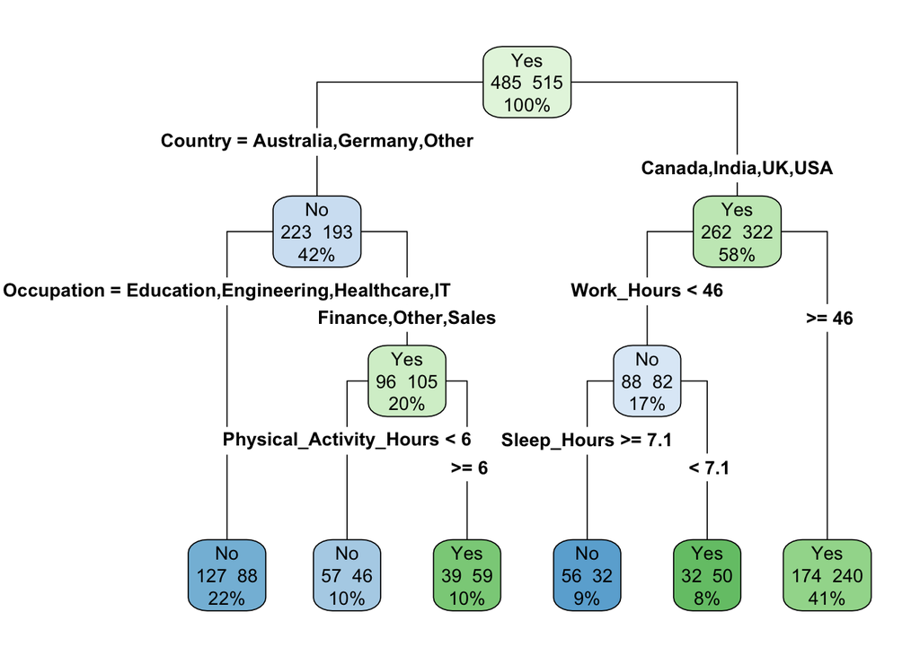

```r
# Prune the tree
pruned_tree <- prune(tree_model, cp = 0.01752577) # Choose optimal CP based on cv_model
rpart.plot(pruned_tree, type = 4, extra = 101)
```

```r
# Evaluate predictions
predictions <- predict(pruned_tree, mh, type = "class")
confusion_matrix <- table(Predicted = predictions, Actual = mh$Mental_Health_Condition)
print(confusion_matrix)
```

```
##          Actual
## Predicted  No Yes
##       No  240 166
##       Yes 245 349
```

```r
# Display the complexity parameter table
printcp(pruned_tree)
```

```
##
## Classification tree:
## rpart(formula = Mental_Health_Condition ~ Age + Gender + Occupation +
##     Country + Stress_Level + Consultation_History + Sleep_Hours +
##     Work_Hours + Physical_Activity_Hours, data = mh, method = "class")
##
## Variables actually used in tree construction:
## [1] Country                 Occupation              Physical_Activity_Hours
## [4] Sleep_Hours             Work_Hours
##
## Root node error: 485/1000 = 0.485
##
## n= 1000
##
##         CP nsplit rel error xerror     xstd
## 1 0.061856      0   1.00000 1.0000 0.032586
## 2 0.024742      1   0.93814 1.0309 0.032601
## 3 0.020619      3   0.88866 1.0268 0.032601
## 4 0.017526      5   0.84742 1.0330 0.032601
```

The pruned tree has a relative error of 0.847 after 5 splits. This is about half as good as the full tree but is much simpler with 5 splits instead of 17 splits.

## 4. Random Forest

### Stress Level Random Forest

```r
library(randomForest)
```

```r
set.seed(128)

# Train a Random Forest model
rf_model <- randomForest(Stress_Level ~ Age + Gender + Occupation + Country +
                        Mental_Health_Condition + Severity + Consultation_History +
                           Sleep_Hours + Work_Hours + Physical_Activity_Hours,
                         data = mh, ntree = 700, mtry = 2)

# View model summary
print(rf_model)
```

```
##
## Call:
##  randomForest(formula = Stress_Level ~ Age + Gender + Occupation +      Country + Mental_Health_Condition + Severity + Consultation_History +      Sleep_Hours + Work_Hours + Physical_Activity_Hours, data = mh,      ntree = 700, mtry = 2)
##                Type of random forest: classification
##                      Number of trees: 700
## No. of variables tried at each split: 2
##
##         OOB estimate of  error rate: 66%
## Confusion matrix:
##        Low Medium High class.error
## Low    116     95  127   0.6568047
## Medium 115     94  111   0.7062500
## High   113     99  130   0.6198830
```

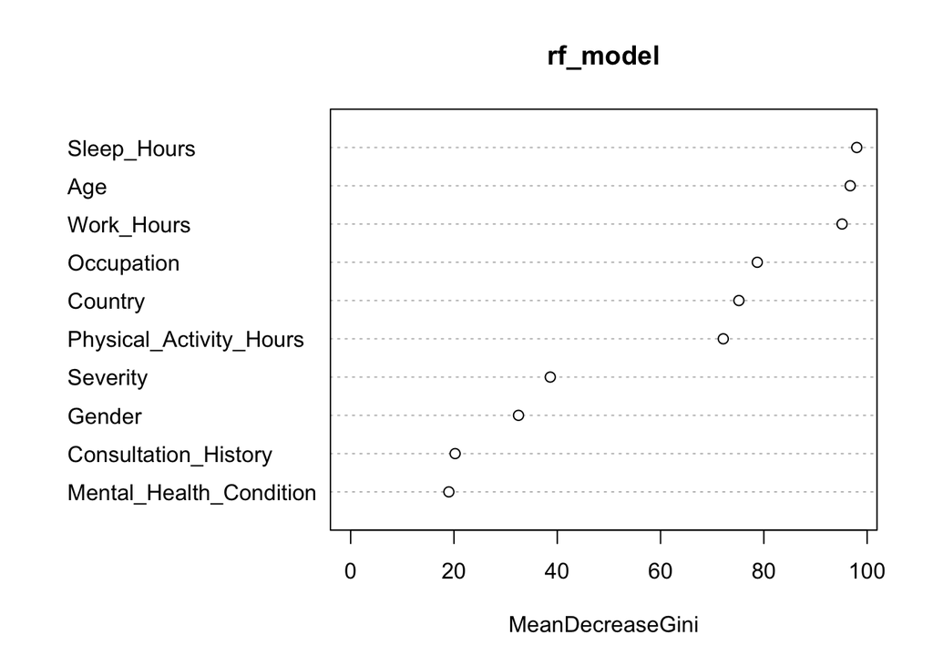

```r
# Plot variable importance
varImpPlot(rf_model)
```

### 5. Clustering

## K-Prototype Clustering

```r
library(clustMixType)
set.seed(126)

clustdata <- mh %>%
  dplyr::select(Gender, Sleep_Hours, Physical_Activity_Hours, Country)

# K-prototypes for mixed data (categorical + numerical)
kprototypes_result <- kproto(clustdata, k = 3)
```

```
## # NAs in variables:
##                  Gender             Sleep_Hours Physical_Activity_Hours
##                       0                       0                       0
##                 Country
##                       0
## 0 observation(s) with NAs.
##
## Estimated lambda: 8.353381
```

```r
print(kprototypes_result$centers)
```

```
##             Gender Sleep_Hours Physical_Activity_Hours   Country
## 1 Other/Didn't Say    7.026683                8.234414    Canada
## 2             Male    7.090370                4.566667 Australia
## 3 Other/Didn't Say    7.183891                1.820669     India
```

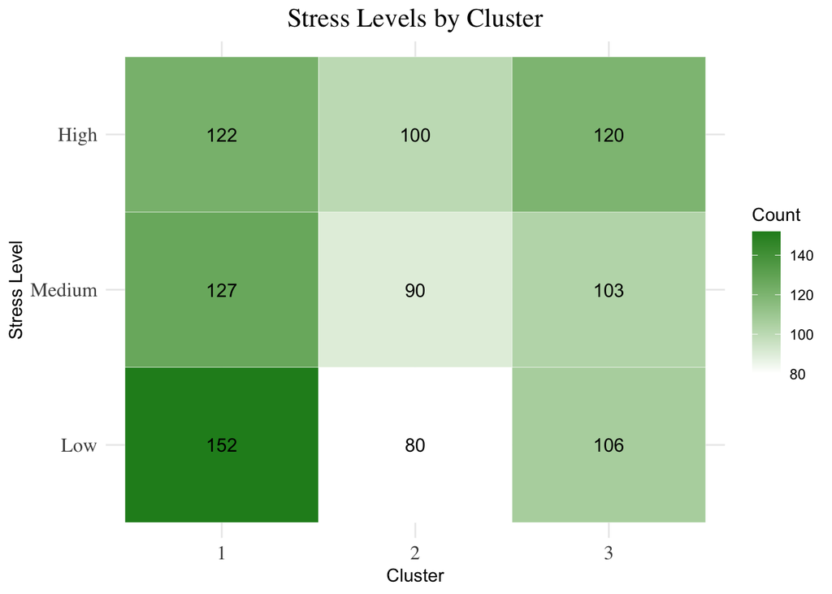

```r
mh$Cluster <- as.factor(kprototypes_result$cluster)

counts <- mh %>%
  group_by(Cluster, Stress_Level) %>%
  summarise(Count = n(), .groups = "drop")

ggplot(counts, aes(x = Cluster, y = Stress_Level, fill = Count)) +
  geom_tile(color = "white") + # Create tiles with borders
  geom_text(aes(label = Count), color = "black", size = 4) + # Add counts as text
  scale_fill_gradient(low = "white", high = "forestgreen") + # Adjust the color gradient
  theme_minimal() + # Minimal theme
  labs(
    title = "Stress Levels by Cluster",
    x = "Cluster",
    y = "Stress Level",
    fill = "Count"
  ) +
  theme(
    plot.title = element_text(hjust = 0.5, size = 16, family = "serif"),
    axis.text = element_text(size = 12, family = "serif")
  )
```

```r
contingency_table <- table(mh$Stress_Level, mh$Cluster)
chisq.test(contingency_table)
```

```
##
##  Pearson's Chi-squared test
##
## data:  contingency_table
## X-squared = 6.6498, df = 4, p-value = 0.1556
```

We cannot confirm that there is an association between cluster and stress level.

## Hierarchical Clustering with Gower distance

```r
library(cluster)  # For Gower distance and clustering
```

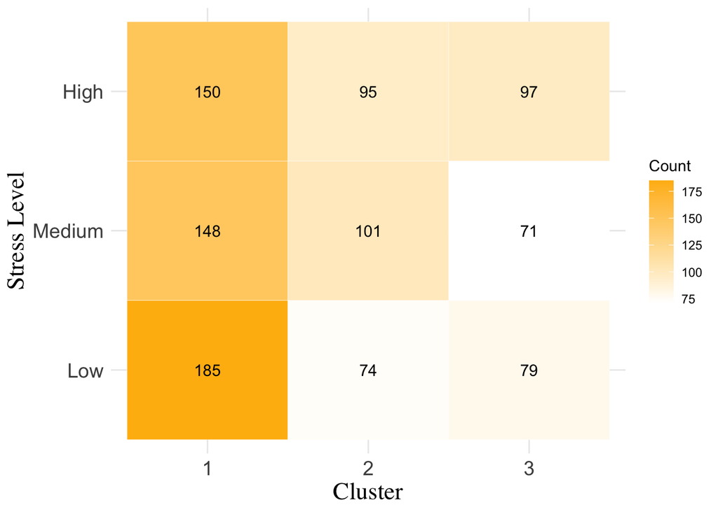

```r
set.seed(126)

clustdata <- dplyr::select(mh, Gender, Sleep_Hours, Physical_Activity_Hours, Country)

# Compute Gower distance for mixed data
gower_dist <- daisy(clustdata, metric = "gower")

# Hierarchical clustering using Gower distance
hclust_result <- hclust(as.dist(gower_dist), method = "average")

# Cut the dendrogram into clusters
clusters <- cutree(hclust_result, k = 3)

mh$Cluster <- as.factor(clusters)

counts <- mh %>%
  group_by(Cluster, Stress_Level) %>%
  summarise(Count = n(), .groups = "drop")

ggplot(counts, aes(x = Cluster, y = Stress_Level, fill = Count)) +
  geom_tile(color = "white") + # Create tiles with borders
  geom_text(aes(label = Count), color = "black", size = 4) + # Add counts as text
  scale_fill_gradient(low = "white", high = "darkgoldenrod1") + # Adjust the color gradient
  theme_minimal() + # Minimal theme
  labs(
    x = "Cluster",
    y = "Stress Level",
    fill = "Count"
  ) +
  theme(
    axis.title = element_text(size = 17, family = "serif"),
    axis.text.x = element_text(size = 14),
    axis.text.y = element_text(size = 14)
  )
```

It appears that cluster 1 has mostly low stress levels, cluster 2 has mostly medium stress levels, and cluster 3 has mostly high stress levels.

```r
contingency_table <- table(mh$Stress_Level, mh$Cluster)
chisq.results <- chisq.test(contingency_table)
print(chisq.results)
```

```
##
##  Pearson's Chi-squared test
##
## data:  contingency_table
## X-squared = 13.296, df = 4, p-value = 0.009918
```

```r
chisq.results$stdres
```

```
##
##                   1          2          3
##   Low     2.9091975 -2.5990231 -0.6953860
##   Medium -0.8899294  2.2293595 -1.2638067
##   High   -2.0258093  0.3994039  1.9361564
```

The Chi-squared test confirms that the clusters and stress level are associated. It also confirms my observation about what cluster is with each stress level except cluster 2 is more strongly associated with not having low stress levels than with having medium stress levels.

### Get “Centers” of each Cluster

```r
# Mode Function
get_mode <- function(x) {
  uniqx <- unique(x)
  uniqx[which.max(tabulate(match(x, uniqx)))]
}

# Compute cluster centers
cluster_centers1 <- mh %>%
  group_by(Cluster) %>%
  summarise(
    Gender = get_mode(Gender),
    Country = get_mode(Country),
    Occupation = get_mode(Occupation),
    Mental_Health_Condition = get_mode(Mental_Health_Condition)
  )

cluster_centers2 <- mh %>%
  group_by(Cluster) %>%
  summarise(
    Severity = get_mode(Severity),
    Consultation_History = get_mode(Consultation_History),
    Age = mean(Age)
  )

cluster_centers3 <- mh %>%
  group_by(Cluster) %>%
  summarise(
    Physical_Activity_Hours = mean(Physical_Activity_Hours),
    Work_Hours = mean(Work_Hours),
    Sleep_Hours = mean(Sleep_Hours)
  )

print(cluster_centers1)
```

```
## # A tibble: 3 × 5
##   Cluster Gender           Country   Occupation Mental_Health_Condition
##   <fct>   <fct>            <fct>     <fct>      <fct>
## 1 1       Other/Didn't Say India     Other      Yes
## 2 2       Female           Germany   Healthcare Yes
## 3 3       Male             Australia Other      Yes
```

```r
print(cluster_centers2)
```

```
## # A tibble: 3 × 4
##   Cluster Severity Consultation_History   Age
##   <fct>   <ord>    <fct>                <dbl>
## 1 1       None     No                    41.6
## 2 2       None     No                    42.3
## 3 3       None     Yes                   42.1
```

```r
print(cluster_centers3)
```

```
## # A tibble: 3 × 4
##   Cluster Physical_Activity_Hours Work_Hours Sleep_Hours
##   <fct>                     <dbl>      <dbl>       <dbl>
## 1 1                          5.27       55.6        7.04
## 2 2                          4.96       53.8        7.25
## 3 3                          5.06       53.6        7.03
```

The most common group in cluster 1 are Indians who didn’t put or put other for their gender, exercise about 5.27 hours per week, and sleep about 7.04 hours per night. The most common group in cluster 2 are female Germans who exercise about 4.96 hours per week and sleep about 7.25 hours per night. The most common group in cluster 3 are male Australians who exercise about 5.06 hours per week and sleep about 7.03 hours per night. These are the most common groups per cluster, but these groups make up a very small portion of the cluster.